# Continuous Auto-RQA

Fred Hasselman

1/14/2019

# 3 Phase Space Reconstruction and Continuous Auto-RQA

## 3.1 **Phase Space Reconstruction**

Here is a great video summary of the phase space reconstruction technique: https://youtu.be/6i57udsPKms

**R-packages for Phase Space Reconstruction**

Package `casnet` relies on packages `fractal` and `rgl` to reconstruct phase space. Package `rgl` is used for plotting and can cause problems on some windows machines. On windows You’ll need to check if you have the [X Window System](http://www.x.org/wiki/) for interactive 3D plotting. This Linux desktop system comes installed in some way or form on most Mac and Windows systems. You can test if it is present by running `rgl::open3d()` in `R`, which will try to open an interactive plotting device.

### 3.1.1 Reconstruct the Lorenz attractor

Package `fractal` includes the 3 dimensions of the Lorenz system in the chaotic regime. Run this code `rgl::plot3d(lorenz,type="l")` with all three packages loaded to get an interactive 3D plot of this strange attractor.

We’ll reconstruct the attractor based on just dimension `X` of the system using the data from package `fractal`, and functions from package `casnet`. Don’t forget: *always look at the manual pages of a function* you are running.

Package `fractal` and package `nonlinearTseries` use functions with similar names, perhapp better to not load them together, or always use `fractal::` and `nonlinearTseries::` if you want to call the functions direclty.

#### Questions

- Use `lx <- lorenz[1:2048,1]` to reconstruct the phase space based on `lx`.
  - Find an optimal embedding lag and dimension by calling `crqa_parameters()`.
  - Use `nnThres = .01`. This is the proportion of remaining nearest neighbours below which we consider the number of dimensions optimal. Because this time series was generated by a simulation of a system, we can use a much lower threshold. For real data, which is much noisier, you can use `0.1` or `0.2`.
  - **NOTE:** If you have a slow computer don’t use `2048`, but use e.g. `512`.

This `crqa_parameters()` function will call several other functions (e.g. `fractal::timeLag()` with `method = "mutual"` and `nonlinearTseries::findAllNeighbours()` for the false nearest neighbourhood search). Look at the manual page, you can run the `crqa_parameters()` function with the defaults settings, it will show a diagnostic plot. Because we have to search over a range of parameters it can take a while to get the results…

- Based on the output:
  - Choose an embedding lag $\tau$ (in `casnet` functions this is the argument `emLag`). Remember, this is just an optimisation choice. Sometimes there is no first minimum, or no global minimum.
  - Find an appropriate embedding dimension by looking when the false nearest neighbours drop below 1%.
- Now you can use this information to reconstruct the phase space:
  - Embed the time series using `ts_embed()` (you can also use `fractal::embedSeries()`).
  - Inspect the object that was returned
  - Use `rgl::plot3d()` to plot the reconstructed space. Plot the reconstructed phase space. (You’ll need to use `as.matrix()` on the object created by `fractal::embedSeries()`)

#### Answers

- Use `lx <- lorenz[1:2048,1]` to reconstruct the phase space based on `lx`.
  - Find an optimal embedding lag and dimension by calling `crqa_parameters()`.

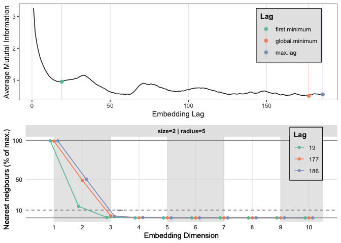

```r
library(rgl)
library(ggplot2)
library(fractal)
library(invctr)
library(casnet)

# The X data
lx <- lorenz[1:2048,1]

# Search for the parameters,
params <- crqa_parameters(lx)
```

```r
# Assign the optimal parameters
emLag <- params$optimLag
emDim <- params$optimDim
```

- Now you can use this information to reconstruct the phase space

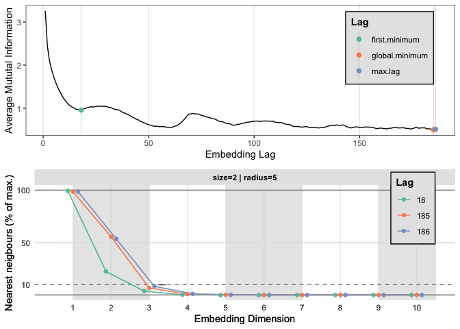

```r
# For X
lx_emb <- ts_embed(y=lx,emLag = emLag, emDim = emDim)

rgl::plot3d(lx_emb, type="l")

# For Y
ly <- lorenz[1:2048,2]

# Search for the parameters,
params <- crqa_parameters(ly)
```

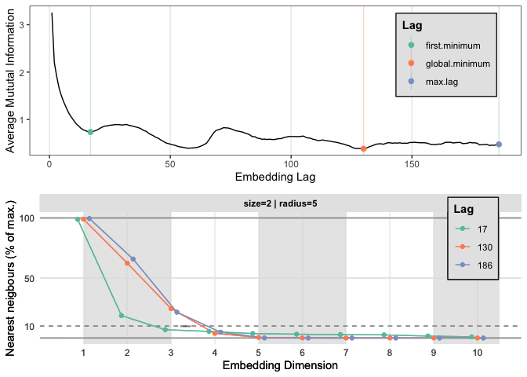

```r
# Assign the optimal parameters
emLag <- params$optimLag
emDim <- params$optimDim

# Embed the time series
ly_emb <- ts_embed(y=ly,emLag = emLag, emDim = emDim)
rgl::plot3d(ly_emb,type="l")

# For Z
lz <- lorenz[1:2048,3]

# Search for the parameters,
params <- crqa_parameters(lz)
```

```r
# Assign the optimal parameters
emLag <- params$optimLag
emDim <- params$optimDim

# Embed the time series
lz_emb <- ts_embed(y=lz,emLag = emLag, emDim = emDim)
rgl::plot3d(lz_emb,type="l")
```

## 3.2 Continuous Auto-RQA

### 3.2.1 RQA of the Lorenz attractor

Perform an RQA on the reconstructed state space of the Lorenz system. You’ll need a radius (also called: threshold, or $\epsilon$) in order to decide which points are close together (recurrent). You have already seen `casnet` provides a function which will automatically select the best parameter settings for phase space reconstruction: `crqa_parameters()`.

#### Questions

- First get a radius that gives you a fixed recurrence rate use `crqa_radius()` look at the manual pages.
- Best way to ensure you are using the same parameters in each function is to create some lists with parameter settings (check the `crqa_cl()` manual to figure out what these parameters mean)

#### Answers

```r
library(fractal)
library(casnet)

# Lorenz X
lx <- lorenz[1:2048,1]
emLag = 17
emDim = 3

(emRad <- crqa_radius(y1 = lx, emLag = emLag, emDim = emDim)$Radius)
```

```
##
## Auto-recurrence: Setting diagonal to (1 + max. distance) for analyses
```

```
## lower and upper are both 0 (no band, just diagonal)
##  using: diag(mat) <- 38.5536...
```

```
##
## Searching for a radius that will yield 0.05 for RR
```

```
##
## Converged! Found an appropriate radius...
```

```
## [1] 3.629007
```

```r
# RQA analysis
(out <- crqa_cl(lx,emDim = emDim, emLag = emLag, emRad = emRad))
```

```
##
## ~~~o~~o~~casnet~~o~~o~~~
##
## Performing auto-RQA
##
## ...using sequential processing...
##
  |o~oo~oo~oo~oo~oo~oo~oo~oo~oo~oo~oo~oo~oo~oo~oo~oo~oo~oo~oo~oo~o| 100%
##
## Completed in:
##    user  system elapsed
##   1.972   0.020   1.998
##
## ~~~o~~o~~casnet~~o~~o~~~
```

```
##                                 .id        RR      DET  DET.RR     LAM
## 1 window: 1 | start: 1 | stop: 2048 0.0499637 0.998963 19.9938 0.99918
##   LAM.DET L_max       L  L_entr         DIV V_max      TT  V_entr      T1
## 1 1.00022  2013 24.6951 3.76081 0.000496771    35 10.1375 2.75883 15.9085
##       T2 W_max  W_mean  W_entr W_prob       F_min emDim emLag    emRad
## 1 175.25  1533 164.849 4.67858     58 0.000652316     3    17 3.629007
##   DLmin VLmin  distNorm
## 1     2     2 EUCLIDEAN
```

We can plot the recurrence matrix…

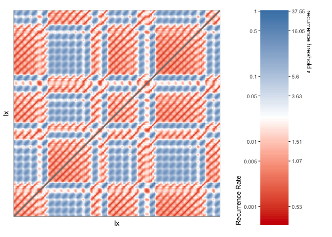

```r
library(casnet)

# Unthresholded matrix (no radius applied)
RM <- rp(y1 = lx, emDim = emDim, emLag = emLag)

# plot it
rp_plot(RM)
```

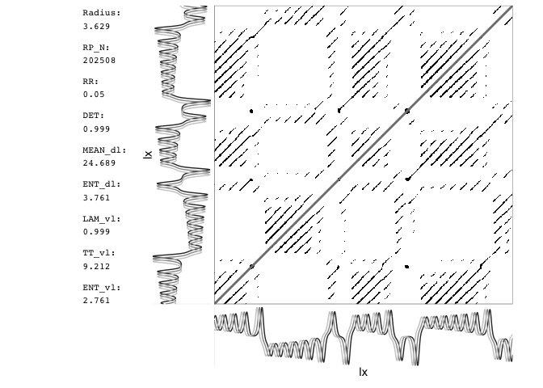

```r
# Thresholded by the radius
RMth <- di2bi(RM,emRad = emRad)

rp_plot(RMth, plotDimensions = TRUE, plotMeasures = TRUE)
```

### 3.2.2 Distinguish between Logistic Map and White noise?

RQA promises to be able to distinguish between different dynamical regimes, for example dynamics due to different parameter settings of the logistic map, see e.g. https://en.wikipedia.org/wiki/Recurrence_quantification_analysis#Time-dependent_RQA

#### Questions

Use RQA to compare white noise to the deterministic chaos series of previous assignments.

```r
library(rio)
library(pracma)

# Reload the data
series <- rio::import("https://github.com/FredHasselman/The-Complex-Systems-Approach-Book/raw/master/assignments/assignment_data/BasicTSA_arma/series.sav", setclass = "tbl_df")
```

#### Answers

Discussed in the next session

### 3.2.3 RQA of circle-tracing data

We’ll analyse a time series recorded from a subject who is tracing a circle using a computer mouse: [circle tracing data](https://github.com/FredHasselman/The-Complex-Systems-Approach-Book/tree/master/assignments/assignment_data/RQA_circletrace).

#### Questions

- Perform an RQA on one of the coordinate series (x or y)
- Study what happens to the RQA measures if you shuffle the temporal order.
- Package `fractal` contains a function `surrogate`. This will create so-called *constrained* realisations of the time series. You can look at the vignette in package `casnet` `cl_CRQA` ([also available in Github](https://github.com/FredHasselman/casnet/tree/master/inst/doc)) Look at the help pages of the function, or study the *Surrogates Manual* of the [TISEAN software](http://www.mpipks-dresden.mpg.de/~tisean/Tisean_3.0.1/index.html) and create two surrogate series, one based on `phase` and one on `aaft`.
  - Look at the RQA measures and think about which $H_0$ should probably be rejected.
  - If you want to be more certain, you’ll have to create a test (more surrogates). The [TISEAN manual](http://www.mpipks-dresden.mpg.de/~tisean/Tisean_3.0.1/docs/surropaper/node5.html#SECTION00030000000000000000) provides all the info you need to construct such a test:

  > “For a minimal significance requirement of 95% , we thus need at least 19 or 39 surrogate time series for one- and two-sided tests, respectively. The conditions for rank based tests with more samples can be easily worked out. Using more surrogates can increase the discrimination power.”

### 3.2.4 EXTRA: Convergent cross mapping

Have a look at the package [`rEDM`, you can use it to do a convergent cross mapping analysis](https://cran.r-project.org/web/packages/rEDM/vignettes/rEDM-tutorial.html)

[Sugihara, G., May, R., Ye, H., Hsieh, C. H., Deyle, E., Fogarty, M., & Munch, S. (2012). Detecting causality in complex ecosystems. science, 338(6106), 496-500.](https://science.sciencemag.org/content/338/6106/496)